# 2016 Michigan Donor Exploratory Data Analysis

Brian Le

January 11, 2016

The 2016 United States presidential election was one of fascinating interest to the entire world. Most of the major polls, such as FiveThirtyEight https://projects.fivethirtyeight.com/2016-election-forecast/, predicted a victory by Hillary Clinton, with Donald Trump’s eventual victory surprising the world. A majority of the so-called “battleground states” were predicted to send their electoral votes to Clinton, but as the results came in, they were won by Trump by narrow margins http://www.cnn.com/election/results/president. In particular, FiveThirtyEight projected a 78.9% chance of victory for Clinton in the state of Michigan https://projects.fivethirtyeight.com/2016-election-forecast/michigan/, where Trump eventually won by ~11700 votes, or a 0.3% margin http://www.cnn.com/election/results/states/michigan#president. Similar scenarios played out in other states, including Wisconsin and Pennsylvania.

# Analysis

This election day defiance of expected results had me wondering; could we have seen this coming by looking at some publicly available information, such as Michigan donor data? Donor data is available for download through the Federal Election Commission http://fec.gov/disclosurep/PDownload.do, and the dataset used in this data exploration is the 2016 Michigan donor dataset ftp://ftp.fec.gov/FEC/Presidential_Map/2016/P00000001/P00000001-MI.zip. Here, I perform exploratory data analysis to examine these donor data.

The dataset includes information such as donor (contrb_nm), donation date (contb_receipt_dt), donation amount (contb_receipt_amt), and donation recipient (cand_nm). Following is a histogram of donations by date.

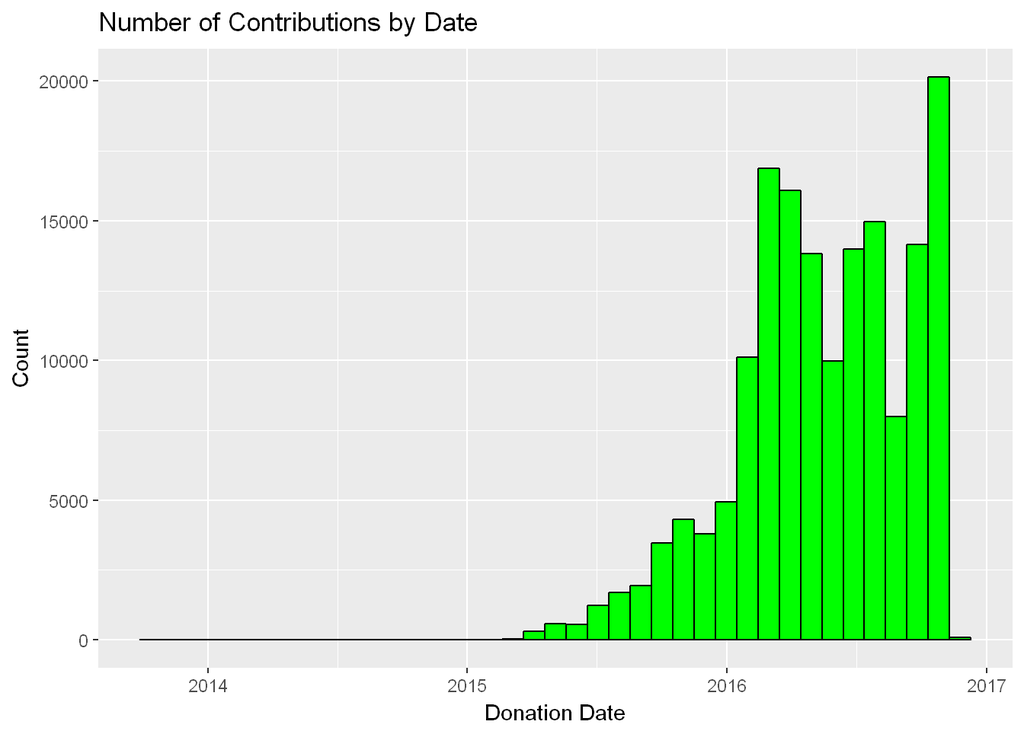

Donations ramp up towards the end of the election cycle (November 8, 2016).

Where do donations come from? We can check the cities with the greatest number of donations in this election cycle.

```
##
##    ANN ARBOR GRAND RAPIDS      DETROIT    KALAMAZOO      LANSING
##        13901         6550         4244         3324         3120
```

These are some of the most populous cities in Michigan, so it makes sense that they also have larger numbers of donations. Donations are also categorized by the election (election_tp), which are the primaries and the general election.

```
##
##         G2016  P2015  P2016  P2020
##    492  52391      1 108211      1
```

In the above table, we see that donations were marked as for the primaries (P2016), for the general election (G2016), for a 2015 primary (P2015) and for the 2020 primary (P2020). 492 were also uncategorized.

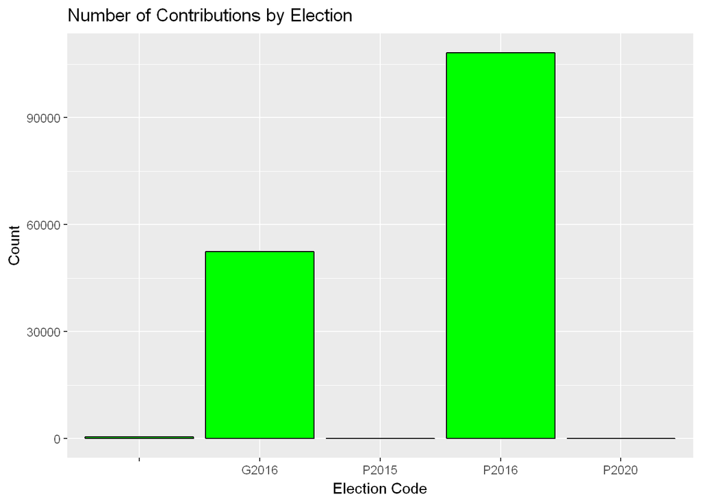

There were about twice as many donations for the primaries than for the general election. We also note that there was no 2015 primary, so that’s likely a miscategorization, and whoever donated to the 2020 primary was 4 years early!

We can take a cursory look at this data to review how many donations each candidate received over the course of the 2016 elections (both primaries and general election).

```
##
##                 Bush, Jeb       Carson, Benjamin S.
##                       768                      9075
##  Christie, Christopher J.   Clinton, Hillary Rodham
##                        18                     68754
## Cruz, Rafael Edward 'Ted'            Fiorina, Carly
##                     11306                       551
##        Graham, Lindsey O.            Huckabee, Mike
##                        40                       117
##             Jindal, Bobby             Johnson, Gary
##                         6                       235
##           Kasich, John R.          Lessig, Lawrence
##                       779                        12
##            McMullin, Evan   O'Malley, Martin Joseph
##                        35                        51
##         Pataki, George E.                Paul, Rand
##                         2                      1012
##    Perry, James R. (Rick)              Rubio, Marco
##                         2                      1726
##          Sanders, Bernard      Santorum, Richard J.
##                     47888                        28
##               Stein, Jill          Trump, Donald J.
##                       177                     18367
##             Walker, Scott     Webb, James Henry Jr.
##                       139                         8
```

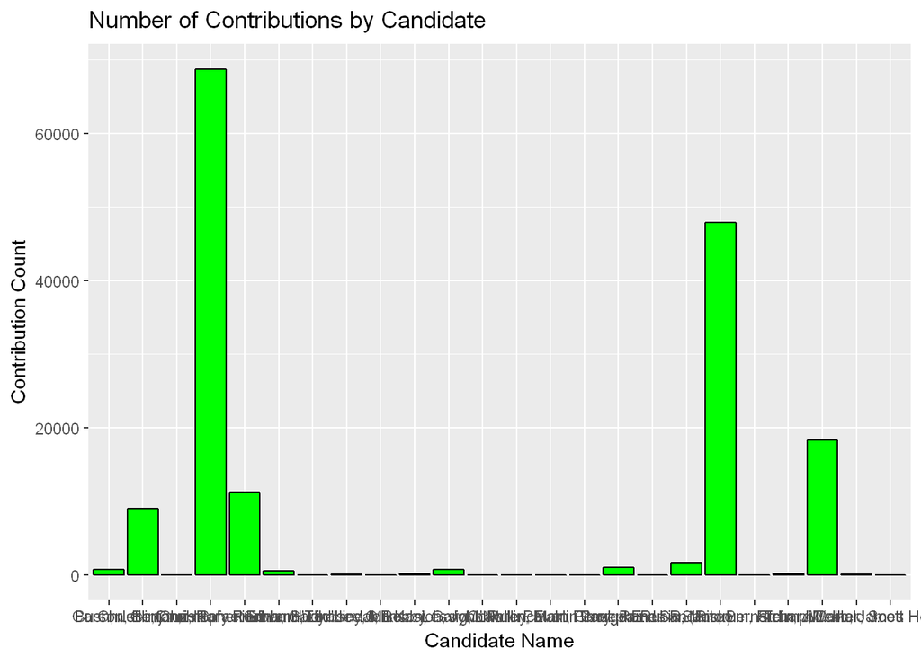

The dataset does not include either political affiliation or gender of the candidates, but we can update that manually using information available from Wikipedia https://en.wikipedia.org/wiki/United_States_presidential_election,_2016.

```
##
##  Democratic       Green Independent Libertarian  Republican
##      116713         177          35         235       43936
```

Tables are useful, but plots are a nice visual aid, so let’s stack these counts next to each other!

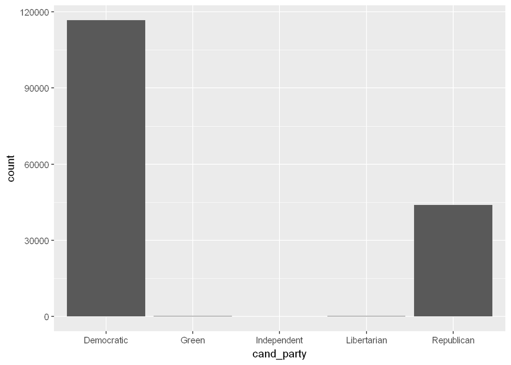

We can also look at donation by party for just the general election.

```
##
##  Democratic       Green Independent Libertarian  Republican
##       43815          90          24         225        8237
```

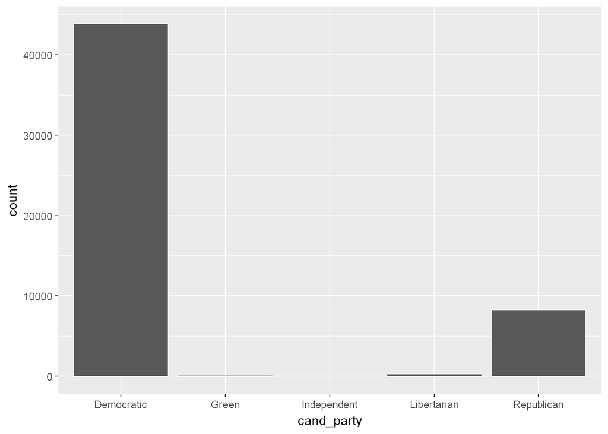

We can also explore relationships between these variables. What about contributions by candidate gender for the primaries and the general election?

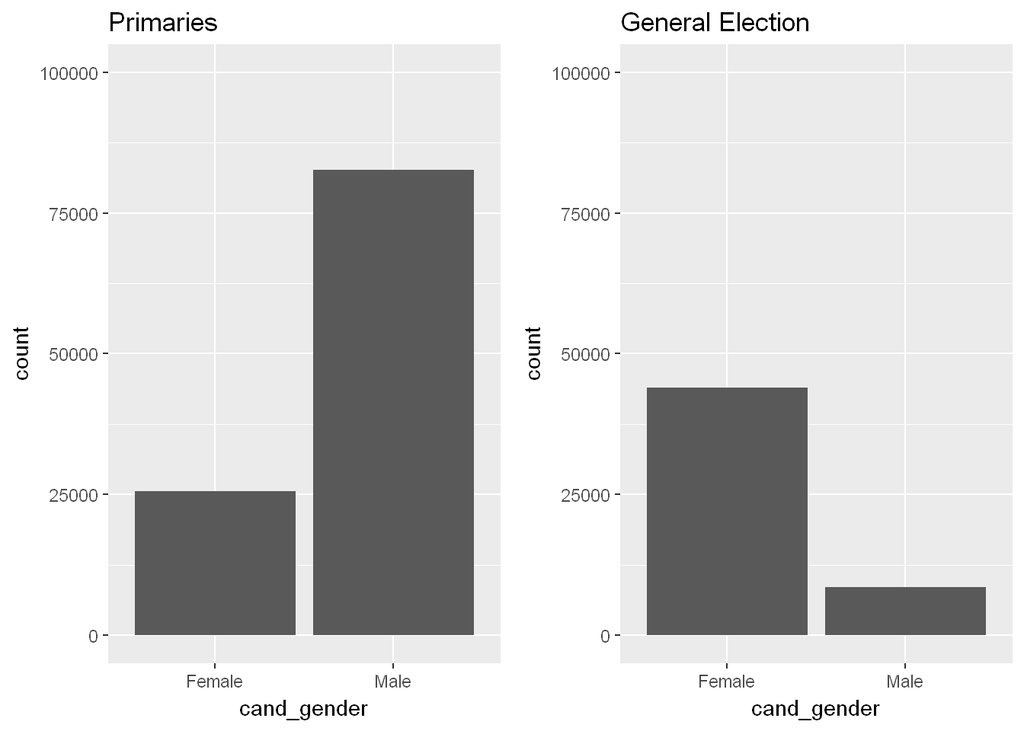

The primaries distribution makes sense given the context that there were many more male candidates in both major primaries (Republican and Democratic) than there were female candidates. The general election distribution is more surprising given the even split of major nominees: 1 major party female (Clinton), 1 minor party female (Stein), 1 major party male (Trump), and 1 minor party male (Johnson).

What does a histogram of donation amounts look like?

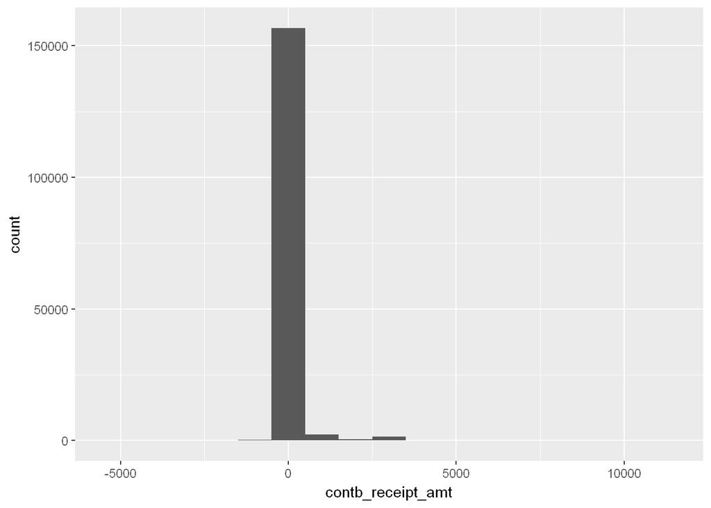

Most donations fit in that bin around $0, but some are negative, which are returned donations. What about donations to only female candidates?

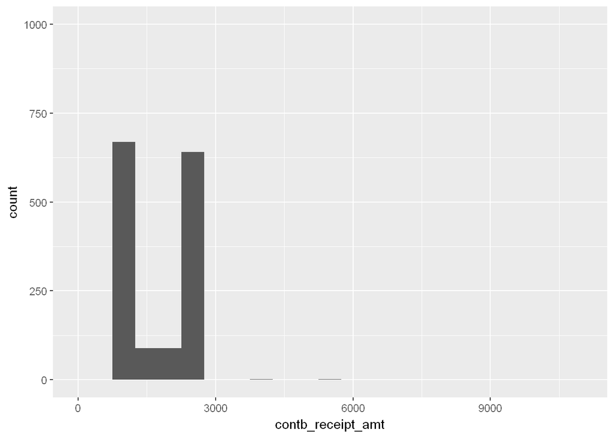

We can also look at how much total money each candidate raised over this election cycle. Since there are so many candidates, this is probably more useful in table format for now.

```
## donors$cand_nm: Bush, Jeb
## [1] 966774.5
## --------------------------------------------------------
## donors$cand_nm: Carson, Benjamin S.
## [1] 963034.7
## --------------------------------------------------------
## donors$cand_nm: Christie, Christopher J.
## [1] 24325
## --------------------------------------------------------
## donors$cand_nm: Clinton, Hillary Rodham
## [1] 6533138
## --------------------------------------------------------
## donors$cand_nm: Cruz, Rafael Edward 'Ted'
## [1] 919226.9
## --------------------------------------------------------
## donors$cand_nm: Fiorina, Carly
## [1] 104016
## --------------------------------------------------------
## donors$cand_nm: Graham, Lindsey O.
## [1] 29635
## --------------------------------------------------------
## donors$cand_nm: Huckabee, Mike
## [1] 8575
## --------------------------------------------------------
## donors$cand_nm: Jindal, Bobby
## [1] 11300
## --------------------------------------------------------
## donors$cand_nm: Johnson, Gary
## [1] 79256.17
## --------------------------------------------------------
## donors$cand_nm: Kasich, John R.
## [1] 420240.1
## --------------------------------------------------------
## donors$cand_nm: Lessig, Lawrence
## [1] 3450
## --------------------------------------------------------
## donors$cand_nm: McMullin, Evan
## [1] 30257.5
## --------------------------------------------------------
## donors$cand_nm: O'Malley, Martin Joseph
```

[output cut: 16 more lines]

```
## --------------------------------------------------------
## donors$cand_nm: Santorum, Richard J.
## [1] 2491.98
## --------------------------------------------------------
## donors$cand_nm: Stein, Jill
## [1] 19947.56
## --------------------------------------------------------
## donors$cand_nm: Trump, Donald J.
## [1] 2748437
## --------------------------------------------------------
## donors$cand_nm: Walker, Scott
## [1] 82630
## --------------------------------------------------------
## donors$cand_nm: Webb, James Henry Jr.
## [1] 4800
```

We can compare the amounts donated to males and females using side-by-side boxplots.

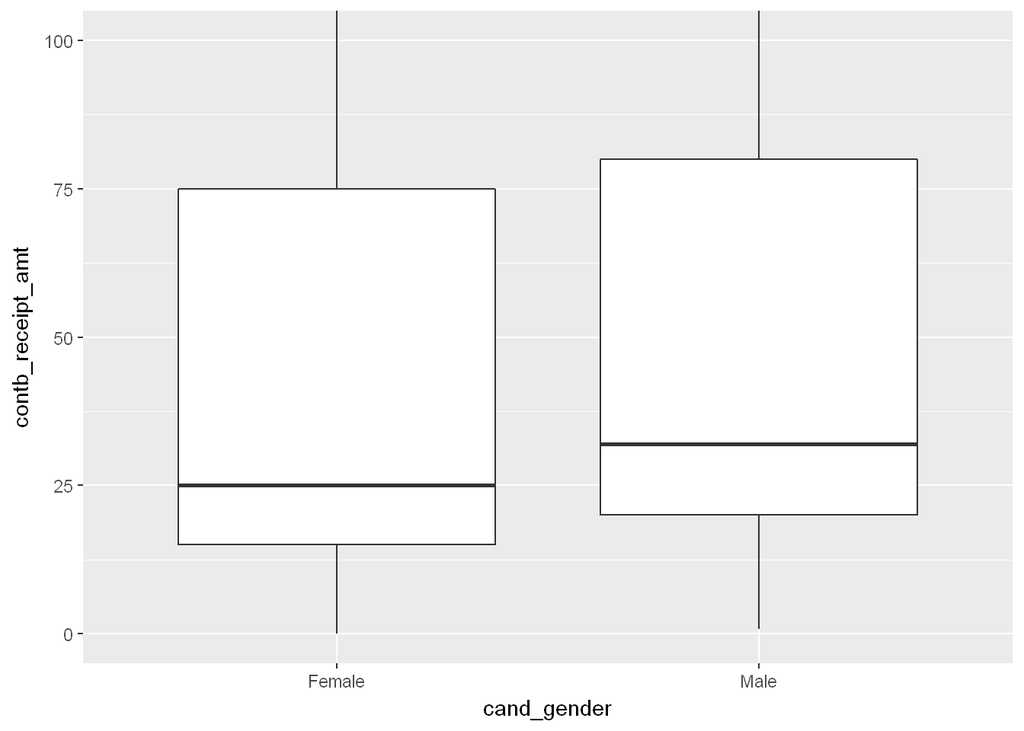

Individual donations to male candidates appear to have been slightly higher than donations to female candidates. We can perform a two sample t-test to see if there’s a significant difference between the two populations using the following hypotheses:

Null hypothesis: there is no difference in donation amounts for either gender. Alternative hypothesis: there is a difference in donation amounts to males vs. to females.

```
##
##  Welch Two Sample t-test
##
## data:  subset(subset(donors, contb_receipt_amt > 0), cand_gender ==  and subset(subset(donors, contb_receipt_amt > 0), cand_gender ==     "Female")$contb_receipt_amt and     "Male")$contb_receipt_amt
## t = -6.7005, df = 157130, p-value = 2.084e-11
## alternative hypothesis: true difference in means is not equal to 0
## 95 percent confidence interval:
##  -13.794884  -7.550975
## sample estimates:
## mean of x mean of y
##  97.49542 108.16835
```

With a p-value smaller than 2.084e-11, we reject the null hypothesis at the alpha = 0.05 level and accept the alternative hypothesis that there is a statistically significant difference between the two populations. That is, donation amounts to male candidates were significantly different from donation amounts to female candidates.

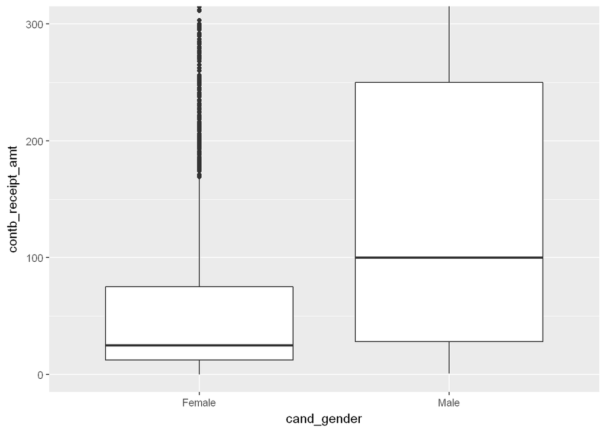

If we look at the same boxplots for only the general election, we see that donations to male candidates were much higher than donations to female candidates.

We can take a cursory look at the boxplot statistics, as well.

```
## donors$cand_gender: Female
##     Min.  1st Qu.   Median     Mean  3rd Qu.     Max.
## -5400.00    11.00    25.00    95.81    75.00  5400.00
## --------------------------------------------------------
## donors$cand_gender: Male
##    Min. 1st Qu.  Median    Mean 3rd Qu.    Max.
##   -5400      16      30     101      80   10800
```

Note that in the general election, the main candidates still running in Michigan were Trump and Johnson (males); and Clinton and Stein (females). This is evidenced by the donation totals to candidates in the general election, outlined below.

```
## genDonors$cand_nm: Bush, Jeb
## [1] 20370
## --------------------------------------------------------
## genDonors$cand_nm: Carson, Benjamin S.
## [1] 31481.5
## --------------------------------------------------------
## genDonors$cand_nm: Clinton, Hillary Rodham
## [1] 3692184
## --------------------------------------------------------
## genDonors$cand_nm: Cruz, Rafael Edward 'Ted'
## [1] 53437
## --------------------------------------------------------
## genDonors$cand_nm: Graham, Lindsey O.
## [1] 8100
## --------------------------------------------------------
## genDonors$cand_nm: Johnson, Gary
## [1] 69200.67
## --------------------------------------------------------
## genDonors$cand_nm: Kasich, John R.
## [1] 21333.8
## --------------------------------------------------------
## genDonors$cand_nm: McMullin, Evan
## [1] 28207.5
## --------------------------------------------------------
## genDonors$cand_nm: Paul, Rand
## [1] 11888.75
## --------------------------------------------------------
## genDonors$cand_nm: Rubio, Marco
## [1] 29185
## --------------------------------------------------------
## genDonors$cand_nm: Stein, Jill
## [1] 6806.56
## --------------------------------------------------------
## genDonors$cand_nm: Trump, Donald J.
## [1] 1749268
## --------------------------------------------------------
## genDonors$cand_nm: Walker, Scott
## [1] 13400
```

How many donors were there total? And how many repeat donors?

```
## [1] 36720
```

```
## [1] 18559
```

Let’s look at donations as a function of amount vs. donation date. We’ll look at donation date as days until the general election, plotting that number as a negative for plotting convenience (e.g. -100 corresponds to 100 days until the general election on November 8, 2016).

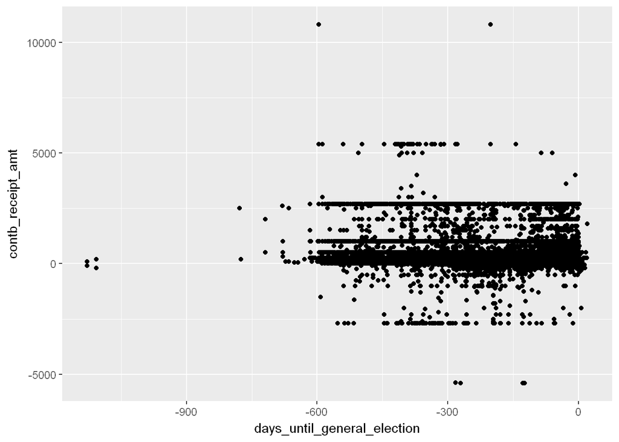

What about looking at only general election donations and in the period of time between the end of the primaries (here we use July 29, 2016, the day after the end of the Democratic National Convention) and the general election date (November 8, 2016), which was 102 days.

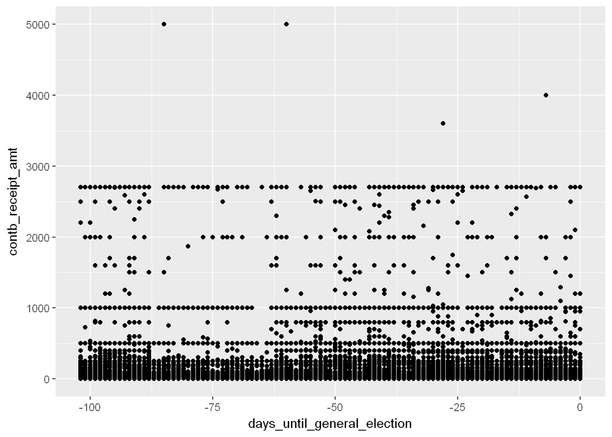

This looks promising; let’s remake the plot but weight the data points so we can see concentrations of donation amounts/dates.

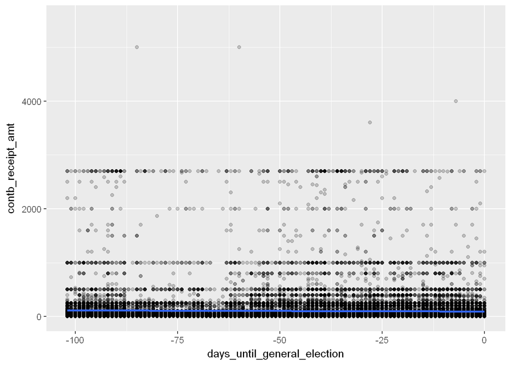

Interestingly, we see some trends emerge, such as the prevalence of small donations and the existence of horizontal lines in the plot. The overlaid blue line is obtained via linear regression and shows that the donation trend is approximately constant through the election cycle.

For donations to male and female candidates, what are the mean and median contributions and how many were there?

```
## # A tibble: 2 × 4
##   cand_gender grouped_mean grouped_median     n
##         <chr>        <dbl>          <dbl> <int>
## 1      Female     95.81044             25 69482
## 2        Male    100.97245             30 91614
```

What about for donations to individual candidates?

```
## # A tibble: 24 × 4
##                      cand_nm grouped_mean grouped_median     n
##                       <fctr>        <dbl>          <dbl> <int>
## 1                  Bush, Jeb   1258.82096           1000   768
## 2        Carson, Benjamin S.    106.11952             50  9075
## 3   Christie, Christopher J.   1351.38889            750    18
## 4    Clinton, Hillary Rodham     95.02193             25 68754
## 5  Cruz, Rafael Edward 'Ted'     81.30434             50 11306
## 6             Fiorina, Carly    188.77677            100   551
## 7         Graham, Lindsey O.    740.87500             50    40
## 8             Huckabee, Mike     73.29060             30   117
## 9              Jindal, Bobby   1883.33333           2700     6
## 10             Johnson, Gary    337.26030            150   235
## # ... with 14 more rows
```

What about donations by donor?

```
## # A tibble: 5 × 5
##                 contbr_nm grouped_mean grouped_median  summed     n
##                    <fctr>        <dbl>          <dbl>   <dbl> <int>
## 1 LEVY, EDWARD C. MR. JR.    1620.0000         2700.0 16200.0    10
## 2      QAZI, MOHAMMAD MR.    3240.0000         5400.0 16200.0     5
## 3    CHERUKURI, SREENIVAS     442.9486          201.6 15503.2    35
## 4  KENNEDY, JULIANNE MRS.    2261.8333         1385.5 13571.0     6
## 5        ANDREWS, CHARLES    1828.5714         2700.0 12800.0     7
```

Let’s take a look at the median donation per day for the entire election season.

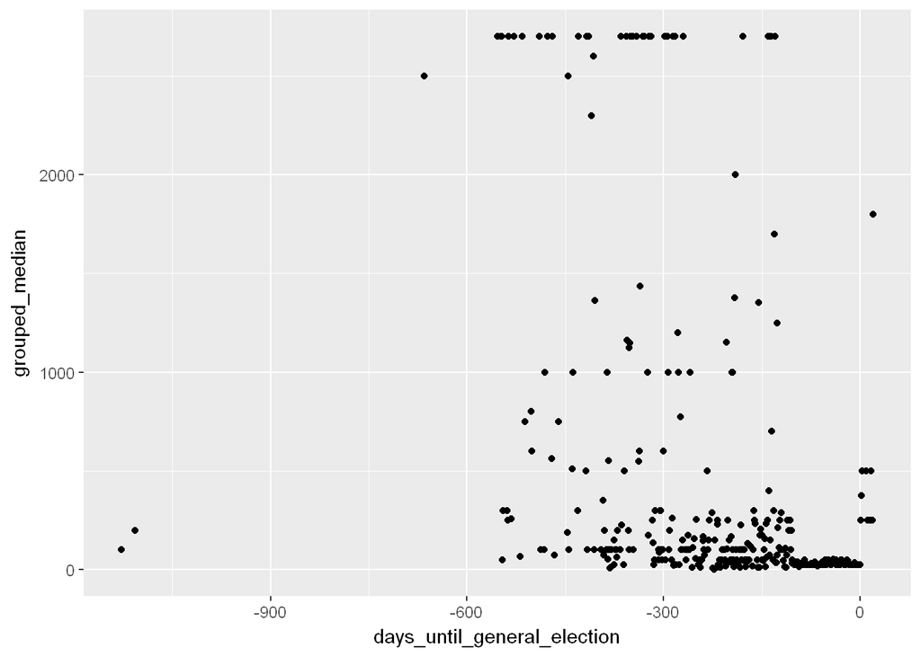

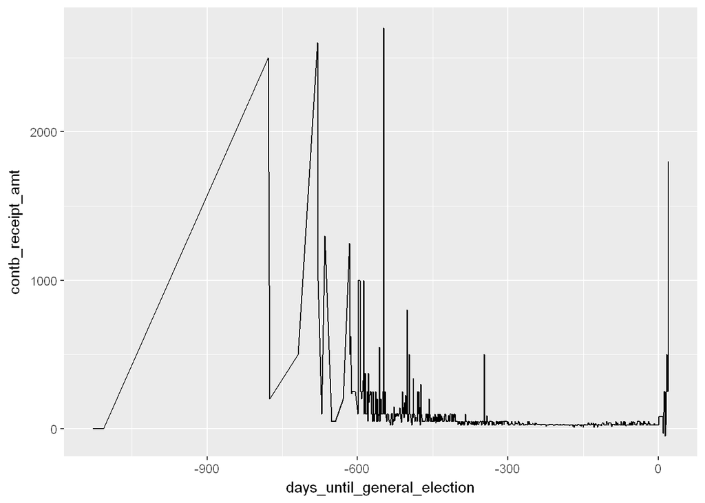

We can also look at the total donations per day.

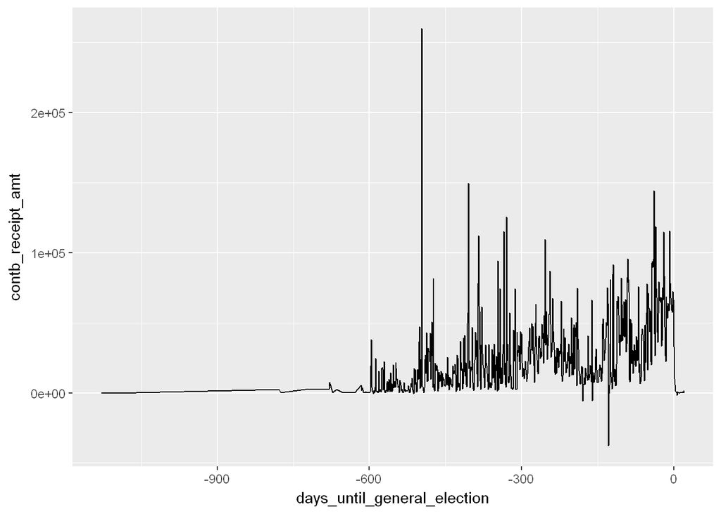

We’ve looked at the total donation amount per day. What if we break it up to total donation amount per day for each political party?

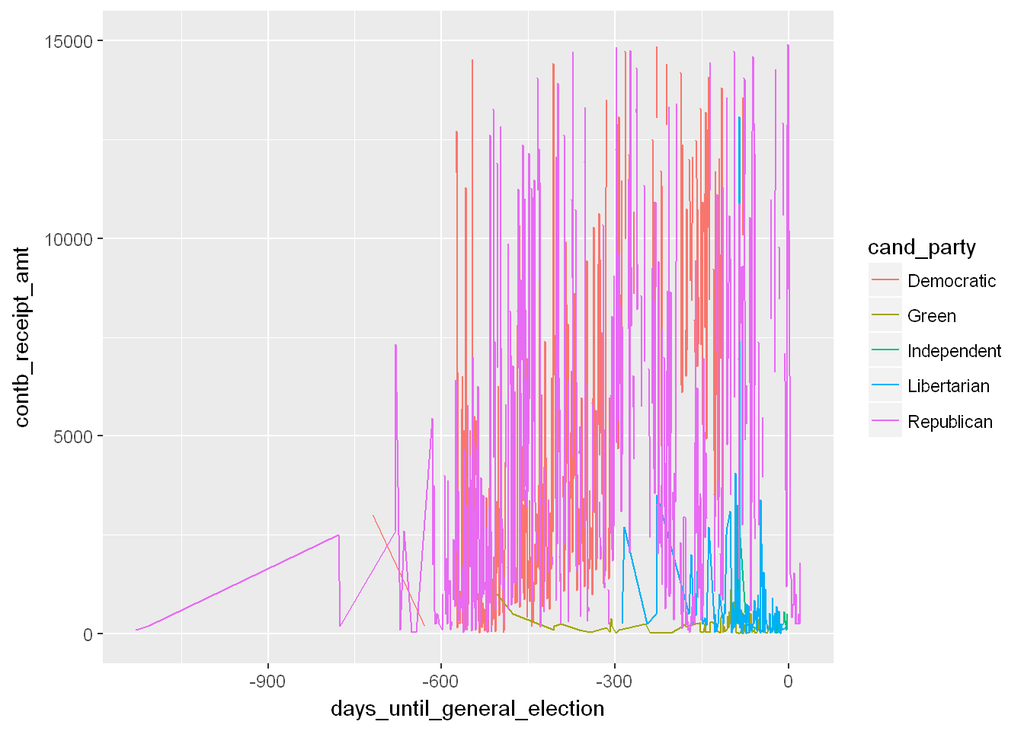

It certainly looks like the Deomcratic and Republican parties lead in daily donations raised compared to the Green party, the Libertarian party, and independents. Let’s narrow down our dataset to donations to the two major candidates of this election cycle: Hillary Clinton and Donald Trump.

```
##
## Clinton, Hillary Rodham        Trump, Donald J.
##                   43605                    7826
```

Hillary Clinton received 43605 total donations for the general election while Donald Trump received 7826. We can look at a summary of this subset of data.

```
##    cmte_id               cand_id                         cand_nm
##  Length:51431       P00003392:43605   Clinton, Hillary Rodham:43605
##  Class :character   P80001571: 7826   Trump, Donald J.       : 7826
##  Mode  :character   P20002671:    0
##                     P20002721:    0
##                     P20003281:    0
##                     P20003984:    0
##                     (Other)  :    0
##                contbr_nm               contbr_city    contbr_st
##  CONGLETON, LISA    :  167   ANN ARBOR       : 6015   MI:51431
##  WEINER, JUDITH     :  115   GRAND RAPIDS    : 1836
##  DELBENE, MIKE      :   93   DETROIT         : 1749
##  KINNEY, CINDY      :   81   LANSING         : 1099
##  HANENBURG, KATHLEEN:   78   BLOOMFIELD HILLS: 1068
##  HELLING, DENISE    :   76   EAST LANSING    : 1051
##  (Other)            :50821   (Other)         :38613
##    contbr_zip                      contbr_employer
##  Min.   :        0   N/A                   :15235
##  1st Qu.:480804239   RETIRED               : 5522
##  Median :482075010   SELF-EMPLOYED         : 4403
##  Mean   :402904626   INFORMATION REQUESTED : 2391
##  3rd Qu.:488541428   UNIVERSITY OF MICHIGAN: 1777
##  Max.   :499699747   (Other)               :22072
##  NA's   :8           NA's                  :   31
##              contbr_occupation contb_receipt_amt contb_receipt_dt
##  RETIRED              :16999   Min.   :   0.01   Min.   :2015-05-10
##  INFORMATION REQUESTED: 2418   1st Qu.:  15.00   1st Qu.:2016-08-25
##  PROFESSOR            : 1727   Median :  28.00   Median :2016-09-29
##  ATTORNEY             : 1514   Mean   : 105.80   Mean   :2016-09-23
##  TEACHER              : 1032   3rd Qu.: 100.00   3rd Qu.:2016-10-25
##  PHYSICIAN            :  918   Max.   :5000.00   Max.   :2016-11-28
##  (Other)              :26823
##                                                            receipt_desc
##                                                                  :51431
##  * EARMARKED CONTRIBUTION: SEE BELOW REATTRIBUTION/REFUND PENDING:    0
##  EARMARKED FROM MAKE DC LISTEN; SEE REDESIGNATION                :    0
##  REATTRIBUTION / REDESIGNATION REQUESTED                         :    0
##  REATTRIBUTION / REDESIGNATION REQUESTED (AUTOMATIC)             :    0
##  REATTRIBUTION / REDESIGNATION REQUESTED SEE REATTRIBUTION       :    0
##  (Other)                                                         :    0
```

[output cut: 9 more lines]

```
##  Min.   :1024052   C10627819:    3        :    0
##  1st Qu.:1112134   C10763192:    3   G2016:51431
##  Median :1126295   C10180094:    2   P2015:    0
##  Mean   :1123243   C10194369:    2   P2016:    0
##  3rd Qu.:1133832   C10197676:    2   P2020:    0
##  Max.   :1133930   C10217158:    2
##                    (Other)  :51417
##  days_until_general_election  cand_party        cand_gender
##  Min.   :-548.00             Length:51431       Length:51431
##  1st Qu.: -75.00             Class :character   Class :character
##  Median : -40.00             Mode  :character   Mode  :character
##  Mean   : -45.89
##  3rd Qu.: -14.00
##  Max.   :  20.00
##
```

```
## # A tibble: 299 × 4
##    days_until_general_election grouped_mean grouped_median     n
##                          <dbl>        <dbl>          <dbl> <int>
## 1                         -548     2700.000        2700.00     1
## 2                         -547     2700.000        2700.00     1
## 3                         -545      300.000         300.00     1
## 4                         -532      137.170         137.17     1
## 5                         -519       67.890          67.89     1
## 6                         -481     1000.000        1000.00     1
## 7                         -477     2133.333        2700.00     3
## 8                         -466     2700.000        2700.00     1
## 9                         -439      250.000         250.00     1
## 10                        -431      300.000         300.00     1
## # ... with 289 more rows
```

Below is plotted the total donations amounts per day received by each candidate.

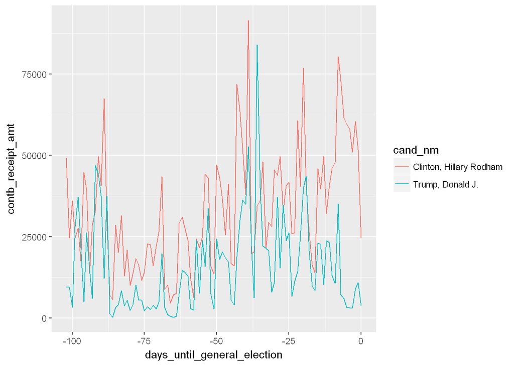

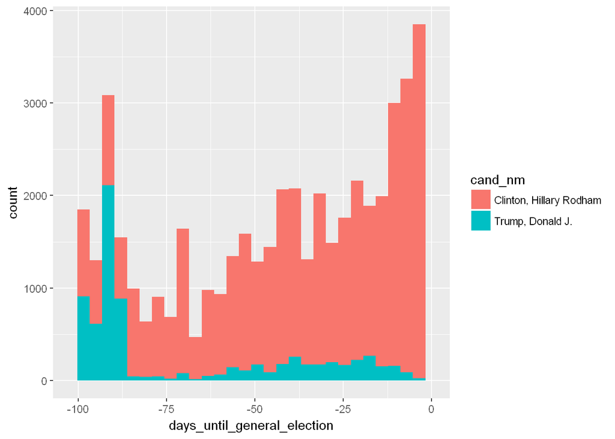

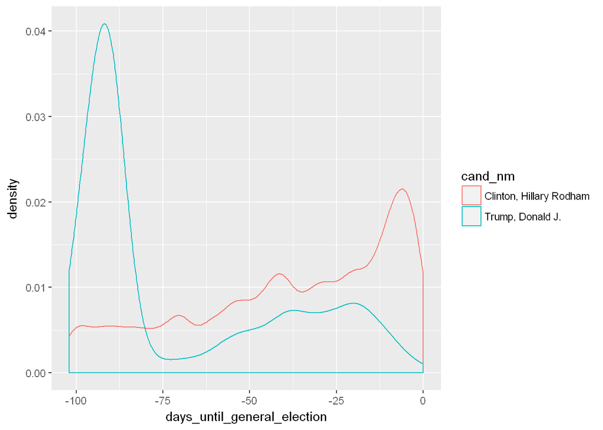

We can see that Clinton received an uptick in donations closing in our election day, whereas Trump had a large surge after the conclusion of the Democratic primary but had faltering donation amounts towards the general election.

Below is plotted the median donation per day for each candidate.

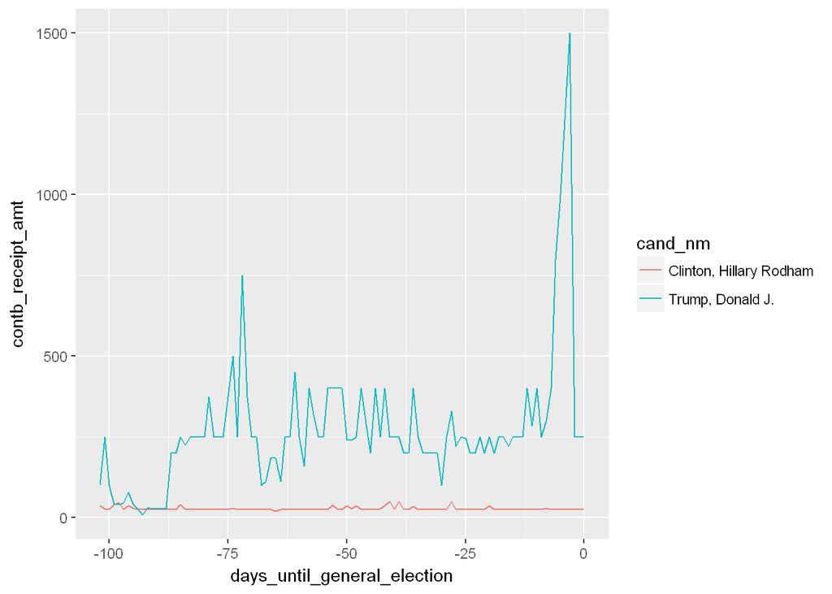

Donations to Trump tended to be in higher amounts than donations to Clinton.

## Final Plots and Summary

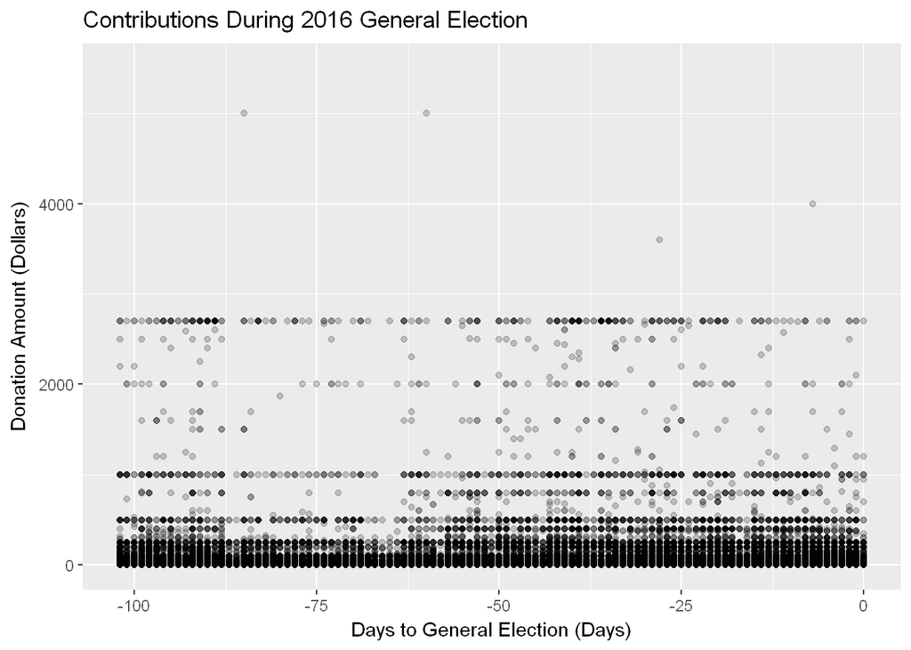

This scatterplot of contributions to political candidates during the general 2016 United States presidential election shows that the majority of donations were relativel small (<$500). Horizontal lines can be observed at specific donation amounts, including $500, $1000, and $2700. We can contextualize this information by looking at both suggested donation amounts and the maximum contribution amount. The Federal Election Commission states that the maximum political contribution made per individual per year is $2700 (http://www.fec.gov/pages/brochures/citizens.shtml), while the donation pages for the Republican Party (https://secure.gop.com/donate) and Democratic Party (https://my.democrats.org/page/contribute/help-democrats-fight-back) have suggested donation amounts of $500 and $1000 among others. These suggested donation amounts seemed to take hold in donor’s minds. (Note that donations over the FEC limit of $2700 result in “negative” donations, or refunded donations.)

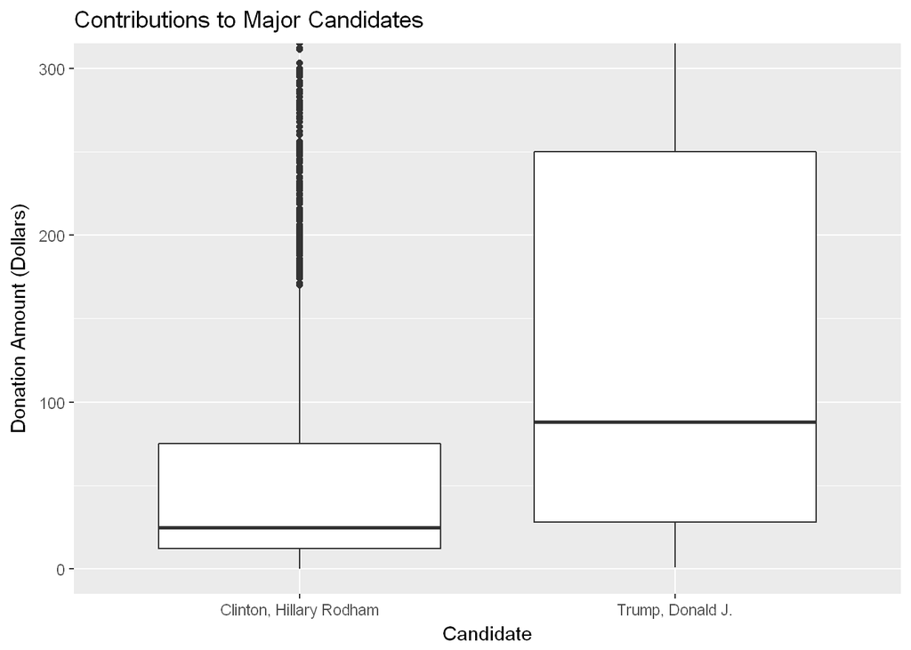

We can again perform a t-test in order to see if the differences in donation amounts are statistically significant with the following hypotheses:

Null hypothesis: there is no difference in sizes of donations made to either Hillary Clinton or Donald Trump. Alternative hypothesis: there is a difference in sizes of donations made to Hillary Clinton vs. to Donald Trump.

```
##
##  Welch Two Sample t-test
##
## data:  subset(subset(majorParty, contb_receipt_amt > 0), cand_nm ==  and subset(subset(majorParty, contb_receipt_amt > 0), cand_nm ==     "Clinton, Hillary Rodham")$contb_receipt_amt and     "Trump, Donald J.")$contb_receipt_amt
## t = -29.535, df = 8905.2, p-value < 2.2e-16
## alternative hypothesis: true difference in means is not equal to 0
## 95 percent confidence interval:
##  -148.0618 -129.6314
## sample estimates:
## mean of x mean of y
##   84.6734  223.5200
```

With a p-value smaller than 2.2e-16, we reject the null hypothesis at the alpha = 0.05 level and find that there is a statistically significant difference in the sizes of donations made to Clinton vs. Trump.

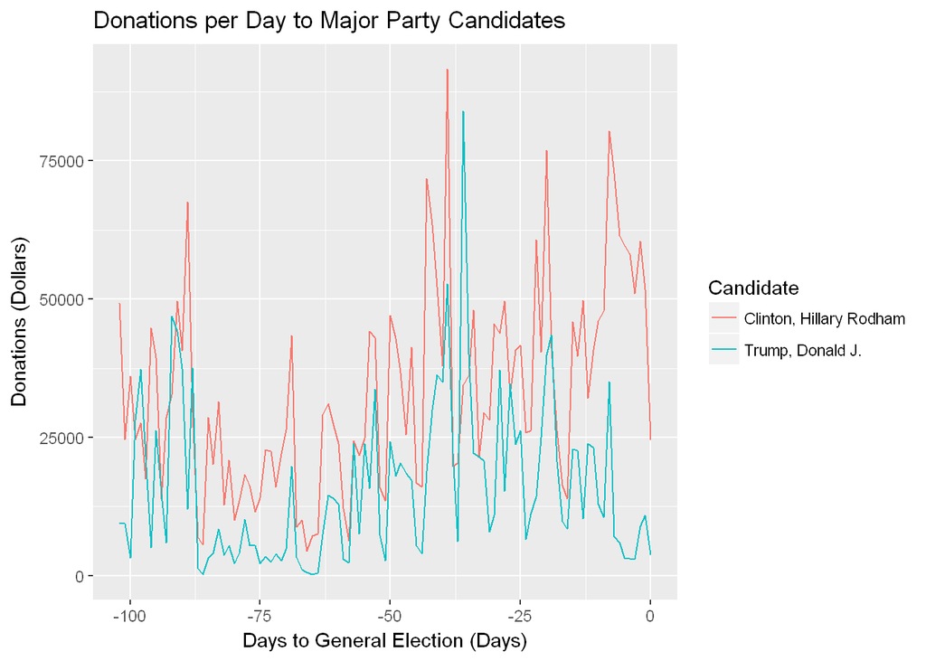

In this plot, we track the daily donation totals to both Clinton and Trump. While the boxplots revealed that individual donations to Trump were higher, Clinton still received a larger amount of money per day in Michigan. In total, Clinton received ~$3.7 million while Trump received ~$1.75 million. Considering the average amount of a donation to Clinton was much lower than to Trump, Clinton must have received many more donations than Trump (43605 to 7826). Each person of voting age is entitled to a single vote, so if the number of donations made was reflective of the general voting trend, we would’ve expected Clinton to win, especially given the surge of donations to Clinton in the waning days of the campaign. And while a Clinton victory was the expected case, a narrow Trump victory was the eventual outcome.

### Reflection

The most difficult part of this analysis was picking compelling directions to move the analysis in. The initial thought of simply looking at donation counts already opened many doors of exploration, such as looking at the donation amount and the date of the donation and even categorizing by candidate or election.

I went into this analysis expecting to find that, given Trump’s surprise win in Michigan, that the donations would provide some underlying context. My expectation was that donations to Trump, both in count and amount, would have increased as election day approached. However, I was surprised to find the opposite; even though Clinton received an uptick in donations as the election cycle ended and received many more donations by a large margin, it was Trump who was victorious. Perhaps those who voted for Trump didn’t feel strongly enough to donate to him, or those who voted for Clinton were more likely to feel strongly enough to donate, or perhaps donations and preference are not as correlated as I’d hoped.

The analysis definitely has many more directions that could be taken, such as looking at political party preference by occupation. Given the wide-range of reported occupations (with retired being the most reported), it would’ve taken a prohibitively large amount of time to categorize the occupations and examine possible relationships between occupation and political party or preferred candidate. This type of analysis could also be easily repeated for other battleground states where the voting was close.